# Association Rules II

Margaret Miró

21746 Data Mining 2022-23

## Association Rules: ECLAT

Let’s continue learning other aspects of rule mining. In the slides you have a more detailed explanation on how ECLAT (Equivalence Class Transformation) constructs the frequent itemsets.

We have been considering Apriori as the basic algorithm for finding association rules, but there are others. The “arules” library also offers ECLAT. ECLAT improves Apriori in the step of extracting frequent itemsets. As you remember, Apriori has to scan the database multiple times to find the frequent itemsets. But with ECLAT there is no need to scan the database for counting the support for k-itemsets (k>=1). The basic idea for the eclat algorithm is use tidset intersections to compute the support of a candidate itemset avoiding the generation of subsets that does not exist in the prefix tree. It was originally proposed by Zaki, Parthasarathy et al.

Let’s start with a simple example where we create a list of items:

```r
mydata <- list(
  c("a", "b", "c"),
  c("a", "b"),
  c("a", "b", "d"),
  c("b", "e"),
  c("b", "c", "e"),
  c("a", "d", "e"),
  c("a", "c"),
  c("a", "b", "d"),
  c("c", "e"),
  c("a", "b", "d", "e")
)
```

The function “eclat()” gives frequent itemsets as an output. Afterwards, the command “ruleInduction()” extracts the rules from those itemsets. For the same minimum support, both algorithms (Apriori and Eclat) must give the same result.

```r
library(arules)
## Mine itemsets with tidLists.
f <- eclat(mydata, parameter = list(support = 0.1, tidLists = TRUE))
```

```
## Eclat
##
## parameter specification:
##  tidLists support minlen maxlen            target  ext
##      TRUE     0.1      1     10 frequent itemsets TRUE
##
## algorithmic control:
##  sparse sort verbose
##       7   -2    TRUE
##
## Absolute minimum support count: 1
##
## create itemset ...
## set transactions ...[5 item(s), 10 transaction(s)] done [0.00s].
## sorting and recoding items ... [5 item(s)] done [0.00s].
## creating bit matrix ... [5 row(s), 10 column(s)] done [0.00s].
## writing  ... [21 set(s)] done [0.00s].
## Creating S4 object  ... done [0.00s].
```

```r
## Get dimensions of the tidLists.
dim(tidLists(f))
```

```
## [1] 21 10
```

```r
## Coerce tidLists to list.
as(tidLists(f), "list")
```

```
## $`{b,c,e}`
## [1] 5
##
## $`{a,b,c}`
## [1] 1
##
## $`{a,c}`
## [1] 1 7
##
## $`{b,c}`
## [1] 1 5
##
## $`{c,e}`
## [1] 5 9
##
## $`{a,b,d,e}`
## [1] 10
##
## $`{a,d,e}`
## [1]  6 10
##
## $`{b,d,e}`
## [1] 10
##
## $`{a,b,d}`
## [1]  3  8 10
##
## $`{a,d}`
## [1]  3  6  8 10
##
## $`{b,d}`
## [1]  3  8 10
##
## $`{d,e}`
## [1]  6 10
##
## $`{a,b,e}`
## [1] 10
##
## $`{a,e}`
## [1]  6 10
##
## $`{b,e}`
## [1]  4  5 10
##
## $`{a,b}`
## [1]  1  2  3  8 10
##
## $`{a}`
## [1]  1  2  3  6  7  8 10
##
## $`{b}`
## [1]  1  2  3  4  5  8 10
##
## $`{e}`
## [1]  4  5  6  9 10
##
## $`{d}`
## [1]  3  6  8 10
##
## $`{c}`
## [1] 1 5 7 9
```

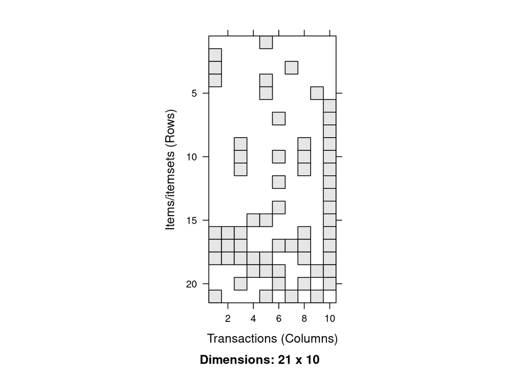

```r
## Inspect visually.
image(tidLists(f))
```

```r
## Show the Frequent itemsets and respective supports
inspect(f)
```

```
##      items        support count
## [1]  {b, c, e}    0.1     1
## [2]  {a, b, c}    0.1     1
## [3]  {a, c}       0.2     2
## [4]  {b, c}       0.2     2
## [5]  {c, e}       0.2     2
## [6]  {a, b, d, e} 0.1     1
## [7]  {a, d, e}    0.2     2
## [8]  {b, d, e}    0.1     1
## [9]  {a, b, d}    0.3     3
## [10] {a, d}       0.4     4
## [11] {b, d}       0.3     3
## [12] {d, e}       0.2     2
## [13] {a, b, e}    0.1     1
## [14] {a, e}       0.2     2
## [15] {b, e}       0.3     3
## [16] {a, b}       0.5     5
## [17] {a}          0.7     7
## [18] {b}          0.7     7
## [19] {e}          0.5     5
## [20] {d}          0.4     4
## [21] {c}          0.4     4
```

In order to work with the “arules” library, the data has to be in transaction format. If necessary, the data has to be converted into a transaction class.

```r
t <- as(mydata, "transactions")
t
```

```
## transactions in sparse format with
##  10 transactions (rows) and
##  5 items (columns)
```

Let’s make sure it’s in the correct format.

```r
str(t)
```

```
## Formal class 'transactions' [package "arules"] with 3 slots
##   ..@ data       :Formal class 'ngCMatrix' [package "Matrix"] with 5 slots
##   .. .. ..@ i       : int [1:27] 0 1 2 0 1 0 1 3 1 4 ...
##   .. .. ..@ p       : int [1:11] 0 3 5 8 10 13 16 18 21 23 ...
##   .. .. ..@ Dim     : int [1:2] 5 10
##   .. .. ..@ Dimnames:List of 2
##   .. .. .. ..$ : NULL
##   .. .. .. ..$ : NULL
##   .. .. ..@ factors : list()
##   ..@ itemInfo   :'data.frame':  5 obs. of  1 variable:
##   .. ..$ labels: chr [1:5] "a" "b" "c" "d" ...
##   ..@ itemsetInfo:'data.frame':  0 obs. of  0 variables
```

Eclat also finds frequent itemsets from data in transaction format and generates the rules.

```r
f2 <- eclat(t, parameter = list(support = 0.1, tidLists = TRUE))
```

```
## Eclat
##
## parameter specification:
##  tidLists support minlen maxlen            target  ext
##      TRUE     0.1      1     10 frequent itemsets TRUE
##
## algorithmic control:
##  sparse sort verbose
##       7   -2    TRUE
##
## Absolute minimum support count: 1
##
## create itemset ...
## set transactions ...[5 item(s), 10 transaction(s)] done [0.00s].
## sorting and recoding items ... [5 item(s)] done [0.00s].
## creating bit matrix ... [5 row(s), 10 column(s)] done [0.00s].
## writing  ... [21 set(s)] done [0.00s].
## Creating S4 object  ... done [0.00s].
```

```r
inspect(f2)
```

```
##      items        support count
## [1]  {b, c, e}    0.1     1
## [2]  {a, b, c}    0.1     1
## [3]  {a, c}       0.2     2
## [4]  {b, c}       0.2     2
## [5]  {c, e}       0.2     2
## [6]  {a, b, d, e} 0.1     1
## [7]  {a, d, e}    0.2     2
## [8]  {b, d, e}    0.1     1
## [9]  {a, b, d}    0.3     3
## [10] {a, d}       0.4     4
## [11] {b, d}       0.3     3
## [12] {d, e}       0.2     2
## [13] {a, b, e}    0.1     1
## [14] {a, e}       0.2     2
## [15] {b, e}       0.3     3
## [16] {a, b}       0.5     5
## [17] {a}          0.7     7
## [18] {b}          0.7     7
## [19] {e}          0.5     5
## [20] {d}          0.4     4
## [21] {c}          0.4     4
```

```r
summary(f2)
```

```
## set of 21 itemsets
##
## most frequent items:
##       b       a       e       d       c (Other)
##      11      10      10       8       6       0
##
## element (itemset/transaction) length distribution:sizes
## 1 2 3 4
## 5 9 6 1
##
##    Min. 1st Qu.  Median    Mean 3rd Qu.    Max.
##   1.000   2.000   2.000   2.143   3.000   4.000
##
## summary of quality measures:
##     support           count
##  Min.   :0.1000   Min.   :1.000
##  1st Qu.:0.2000   1st Qu.:2.000
##  Median :0.2000   Median :2.000
##  Mean   :0.2952   Mean   :2.952
##  3rd Qu.:0.4000   3rd Qu.:4.000
##  Max.   :0.7000   Max.   :7.000
##
## includes transaction ID lists: TRUE
##
## mining info:
##  data ntransactions support
##     t            10     0.1
##                                                               call
##  eclat(data = t, parameter = list(support = 0.1, tidLists = TRUE))
```

```r
rulesf2 <- ruleInduction(f2, confidence = .7)
rulesf2
```

```
## set of 10 rules
```

In order to see the rules:

```r
inspect(rulesf2)
```

```
##      lhs          rhs support confidence lift
## [1]  {b, d, e} => {a} 0.1     1.0000000  1.428571
## [2]  {a, b, e} => {d} 0.1     1.0000000  2.500000
## [3]  {d, e}    => {a} 0.2     1.0000000  1.428571
## [4]  {a, e}    => {d} 0.2     1.0000000  2.500000
## [5]  {b, d}    => {a} 0.3     1.0000000  1.428571
## [6]  {a, d}    => {b} 0.3     0.7500000  1.071429
## [7]  {d}       => {a} 0.4     1.0000000  1.428571
## [8]  {d}       => {b} 0.3     0.7500000  1.071429
## [9]  {b}       => {a} 0.5     0.7142857  1.020408
## [10] {a}       => {b} 0.5     0.7142857  1.020408
```

## Association Rules using Apriori: Titanic example

### Dataset

The Titanic data set provides information on the fate of passengers on the fatal maiden voyage of the ocean liner ‘Titanic’, summarized according to economic status (class), sex, age and survival. This dataset is available in the R package datasets.

```r
str(Titanic)
```

```
##  'table' num [1:4, 1:2, 1:2, 1:2] 0 0 35 0 0 0 17 0 118 154 ...
##  - attr(*, "dimnames")=List of 4
##   ..$ Class   : chr [1:4] "1st" "2nd" "3rd" "Crew"
##   ..$ Sex     : chr [1:2] "Male" "Female"
##   ..$ Age     : chr [1:2] "Child" "Adult"
##   ..$ Survived: chr [1:2] "No" "Yes"
```

The data is organized in a 4-dimensional array resulting from cross-tabulating 2201 observations on 4 variables.

```r
Titanic
```

```
## , , Age = Child, Survived = No
##
##       Sex
## Class  Male Female
##   1st     0      0
##   2nd     0      0
##   3rd    35     17
##   Crew    0      0
##
## , , Age = Adult, Survived = No
##
##       Sex
## Class  Male Female
##   1st   118      4
##   2nd   154     13
##   3rd   387     89
##   Crew  670      3
##
## , , Age = Child, Survived = Yes
##
##       Sex
## Class  Male Female
##   1st     5      1
##   2nd    11     13
##   3rd    13     14
##   Crew    0      0
##
## , , Age = Adult, Survived = Yes
##
##       Sex
## Class  Male Female
##   1st    57    140
##   2nd    14     80
##   3rd    75     76
##   Crew  192     20
```

This dataset is not suitable suitable for association rule mining since we need to have “transactions”. For this example, the rows (transactions) will represent the persons; and the items will be the values of the 4 attributes.

We reconstruct the raw data as titanic.raw in which each row represents a person.

```r
df <- as.data.frame(Titanic)
titanic.raw <- NULL
for (i in 1:4)
{
  titanic.raw <- cbind(
    titanic.raw,
    rep(as.character(df[, i]), df$Freq)
  )
}
titanic.raw <- as.data.frame(titanic.raw)
names(titanic.raw) <- names(df)[1:4]
```

Let’s check the outcome

```r
dim(titanic.raw)
```

```
## [1] 2201    4
```

```r
head(titanic.raw)
```

```
##   Class  Sex   Age Survived
## 1   3rd Male Child       No
## 2   3rd Male Child       No
## 3   3rd Male Child       No
## 4   3rd Male Child       No
## 5   3rd Male Child       No
## 6   3rd Male Child       No
```

To get a general feeling for the data we type

```r
summary(titanic.raw)
```

```
##     Class               Sex                Age              Survived
##  Length:2201        Length:2201        Length:2201        Length:2201
##  Class :character   Class :character   Class :character   Class :character
##  Mode  :character   Mode  :character   Mode  :character   Mode  :character
```

### Frequent Itemsets

Find frequent itemsets for a support of 0.1 and maximum length 4.

```r
freqitem2 <- eclat(titanic.raw, parameter = list(supp = 0.1, maxlen = 4))
```

```
## Eclat
##
## parameter specification:
##  tidLists support minlen maxlen            target  ext
##     FALSE     0.1      1      4 frequent itemsets TRUE
##
## algorithmic control:
##  sparse sort verbose
##       7   -2    TRUE
##
## Absolute minimum support count: 220
##
## create itemset ...
## set transactions ...[10 item(s), 2201 transaction(s)] done [0.00s].
## sorting and recoding items ... [9 item(s)] done [0.00s].
## creating bit matrix ... [9 row(s), 2201 column(s)] done [0.00s].
## writing  ... [35 set(s)] done [0.00s].
## Creating S4 object  ... done [0.00s].
```

```r
summary(freqitem2)
```

```
## set of 35 itemsets
##
## most frequent items:
##   Age=Adult    Sex=Male Survived=No   Class=3rd  Class=Crew     (Other)
##          18          14          12           8           8          14
##
## element (itemset/transaction) length distribution:sizes
##  1  2  3  4
##  9 15  9  2
##
##    Min. 1st Qu.  Median    Mean 3rd Qu.    Max.
##   1.000   1.500   2.000   2.114   3.000   4.000
##
## summary of quality measures:
##     support           count
##  Min.   :0.1186   Min.   : 261.0
##  1st Qu.:0.1838   1st Qu.: 404.5
##  Median :0.2971   Median : 654.0
##  Mean   :0.3404   Mean   : 749.3
##  3rd Qu.:0.3969   3rd Qu.: 873.5
##  Max.   :0.9505   Max.   :2092.0
##
## includes transaction ID lists: FALSE
##
## mining info:
##         data ntransactions support
##  titanic.raw          2201     0.1
##                                                                 call
##  eclat(data = titanic.raw, parameter = list(supp = 0.1, maxlen = 4))
```

```r
inspect(freqitem2)
```

```
##      items                                          support   count
## [1]  {Class=2nd, Age=Adult}                         0.1185825  261
## [2]  {Class=1st, Age=Adult}                         0.1449341  319
## [3]  {Sex=Female, Age=Adult, Survived=Yes}          0.1435711  316
## [4]  {Sex=Female, Age=Adult}                        0.1930940  425
## [5]  {Sex=Female, Survived=Yes}                     0.1562926  344
## [6]  {Class=3rd, Sex=Male, Age=Adult, Survived=No}  0.1758292  387
## [7]  {Class=3rd, Age=Adult, Survived=No}            0.2162653  476
## [8]  {Class=3rd, Sex=Male, Survived=No}             0.1917310  422
## [9]  {Class=3rd, Sex=Male, Age=Adult}               0.2099046  462
## [10] {Class=3rd, Age=Adult}                         0.2848705  627
## [11] {Class=3rd, Sex=Male}                          0.2317129  510
## [12] {Class=3rd, Survived=No}                       0.2398910  528
## [13] {Sex=Male, Age=Adult, Survived=Yes}            0.1535666  338
## [14] {Age=Adult, Survived=Yes}                      0.2971377  654
```

[output cut: 21 more lines]

### Association Rules

Using the frequent itemsets we just found, create the association rules for a 70% confidence.

```r
AR1 <- ruleInduction(freqitem2, confidence = .7)
AR1
```

```
## set of 40 rules
```

We can also create the association rules directly using Apriori (default values):

```r
AR2 <- apriori(titanic.raw)
```

```
## Apriori
##
## Parameter specification:
##  confidence minval smax arem  aval originalSupport maxtime support minlen
##         0.8    0.1    1 none FALSE            TRUE       5     0.1      1
##  maxlen target  ext
##      10  rules TRUE
##
## Algorithmic control:
##  filter tree heap memopt load sort verbose
##     0.1 TRUE TRUE  FALSE TRUE    2    TRUE
##
## Absolute minimum support count: 220
##
## set item appearances ...[0 item(s)] done [0.00s].
## set transactions ...[10 item(s), 2201 transaction(s)] done [0.00s].
## sorting and recoding items ... [9 item(s)] done [0.00s].
## creating transaction tree ... done [0.00s].
## checking subsets of size 1 2 3 4 done [0.00s].
## writing ... [27 rule(s)] done [0.00s].
## creating S4 object  ... done [0.00s].
```

```r
AR2
```

```
## set of 27 rules
```

IMPORTANT: the function apriori(data,…) requires data to be an object of class transactions or any data structure which can be coerced into transactions (a binary matrix or data.frame). You may have to use the function “as()” to force your data to belong to the class transactions before you can apply the “apriori()” function.

The “inspect()” function will give a list of the rules. We have obtained too many rules. We will only consider rules with “Survived=No” and “Survived=Yes” in the right hand side (RHS), non-emptyset in the left hand side and we will also lower the support.

```r
AR3 <- apriori(titanic.raw,
  parameter = list(minlen = 2, support = 0.005, confidence = 0.8),
  appearance = list(rhs = c("Survived=No", "Survived=Yes"), default = "lhs"),
  control = list(verbose = F)
)
inspect(AR3)
```

```
##      lhs                                    rhs            support
## [1]  {Class=2nd, Age=Child}              => {Survived=Yes} 0.010904134
## [2]  {Class=2nd, Sex=Female}             => {Survived=Yes} 0.042253521
## [3]  {Class=2nd, Sex=Male}               => {Survived=No}  0.069968196
## [4]  {Class=1st, Sex=Female}             => {Survived=Yes} 0.064061790
## [5]  {Class=Crew, Sex=Female}            => {Survived=Yes} 0.009086779
## [6]  {Class=3rd, Sex=Male}               => {Survived=No}  0.191731031
## [7]  {Class=2nd, Sex=Female, Age=Child}  => {Survived=Yes} 0.005906406
## [8]  {Class=2nd, Sex=Female, Age=Adult}  => {Survived=Yes} 0.036347115
## [9]  {Class=2nd, Sex=Male, Age=Adult}    => {Survived=No}  0.069968196
## [10] {Class=1st, Sex=Female, Age=Adult}  => {Survived=Yes} 0.063607451
## [11] {Class=Crew, Sex=Female, Age=Adult} => {Survived=Yes} 0.009086779
## [12] {Class=3rd, Sex=Male, Age=Adult}    => {Survived=No}  0.175829169
##      confidence coverage    lift     count
## [1]  1.0000000  0.010904134 3.095640  24
## [2]  0.8773585  0.048159927 2.715986  93
## [3]  0.8603352  0.081326670 1.270871 154
## [4]  0.9724138  0.065879146 3.010243 141
## [5]  0.8695652  0.010449796 2.691861  20
## [6]  0.8274510  0.231712858 1.222295 422
## [7]  1.0000000  0.005906406 3.095640  13
## [8]  0.8602151  0.042253521 2.662916  80
## [9]  0.9166667  0.076328941 1.354083 154
## [10] 0.9722222  0.065424807 3.009650 140
## [11] 0.8695652  0.010449796 2.691861  20
## [12] 0.8376623  0.209904589 1.237379 387
```

### Redundant Rules

Consider rules #1, #7. Rule #1 includes rule #7. Rule #7 provides no extra knowledge in addition to rule #1, since rules #1 tells us that all 2nd-class children survived. When a rule (such as #7) is a super rule of another rule (#1) and the former has the same or a lower lift, the former rule (#7) is considered to be redundant. Let’s order the rules by lift.

```r
rules.sorted <- sort(AR3, by = "lift")
inspect(rules.sorted)
```

```
##      lhs                                    rhs            support
## [1]  {Class=2nd, Age=Child}              => {Survived=Yes} 0.010904134
## [2]  {Class=2nd, Sex=Female, Age=Child}  => {Survived=Yes} 0.005906406
## [3]  {Class=1st, Sex=Female}             => {Survived=Yes} 0.064061790
## [4]  {Class=1st, Sex=Female, Age=Adult}  => {Survived=Yes} 0.063607451
## [5]  {Class=2nd, Sex=Female}             => {Survived=Yes} 0.042253521
## [6]  {Class=Crew, Sex=Female}            => {Survived=Yes} 0.009086779
## [7]  {Class=Crew, Sex=Female, Age=Adult} => {Survived=Yes} 0.009086779
## [8]  {Class=2nd, Sex=Female, Age=Adult}  => {Survived=Yes} 0.036347115
## [9]  {Class=2nd, Sex=Male, Age=Adult}    => {Survived=No}  0.069968196
## [10] {Class=2nd, Sex=Male}               => {Survived=No}  0.069968196
## [11] {Class=3rd, Sex=Male, Age=Adult}    => {Survived=No}  0.175829169
## [12] {Class=3rd, Sex=Male}               => {Survived=No}  0.191731031
##      confidence coverage    lift     count
## [1]  1.0000000  0.010904134 3.095640  24
## [2]  1.0000000  0.005906406 3.095640  13
## [3]  0.9724138  0.065879146 3.010243 141
## [4]  0.9722222  0.065424807 3.009650 140
## [5]  0.8773585  0.048159927 2.715986  93
## [6]  0.8695652  0.010449796 2.691861  20
## [7]  0.8695652  0.010449796 2.691861  20
## [8]  0.8602151  0.042253521 2.662916  80
## [9]  0.9166667  0.076328941 1.354083 154
## [10] 0.8603352  0.081326670 1.270871 154
## [11] 0.8376623  0.209904589 1.237379 387
## [12] 0.8274510  0.231712858 1.222295 422
```

Once the rules are ordered by lift a simple analysis will allow us to find the redundant rules. Or we can find redundant rules automatically.

```r
inspect(rules.sorted[is.redundant(rules.sorted)])
```

```
##     lhs                                    rhs            support
## [1] {Class=2nd, Sex=Female, Age=Child}  => {Survived=Yes} 0.005906406
## [2] {Class=1st, Sex=Female, Age=Adult}  => {Survived=Yes} 0.063607451
## [3] {Class=Crew, Sex=Female, Age=Adult} => {Survived=Yes} 0.009086779
## [4] {Class=2nd, Sex=Female, Age=Adult}  => {Survived=Yes} 0.036347115
##     confidence coverage    lift     count
## [1] 1.0000000  0.005906406 3.095640  13
## [2] 0.9722222  0.065424807 3.009650 140
## [3] 0.8695652  0.010449796 2.691861  20
## [4] 0.8602151  0.042253521 2.662916  80
```

Redundant rules don’t give any additional information and can be pruned.

```r
rules.pruned <- rules.sorted[!is.redundant(rules.sorted)]
inspect(rules.pruned)
```

```
##     lhs                                 rhs            support     confidence
## [1] {Class=2nd, Age=Child}           => {Survived=Yes} 0.010904134 1.0000000
## [2] {Class=1st, Sex=Female}          => {Survived=Yes} 0.064061790 0.9724138
## [3] {Class=2nd, Sex=Female}          => {Survived=Yes} 0.042253521 0.8773585
## [4] {Class=Crew, Sex=Female}         => {Survived=Yes} 0.009086779 0.8695652
## [5] {Class=2nd, Sex=Male, Age=Adult} => {Survived=No}  0.069968196 0.9166667
## [6] {Class=2nd, Sex=Male}            => {Survived=No}  0.069968196 0.8603352
## [7] {Class=3rd, Sex=Male, Age=Adult} => {Survived=No}  0.175829169 0.8376623
## [8] {Class=3rd, Sex=Male}            => {Survived=No}  0.191731031 0.8274510
##     coverage   lift     count
## [1] 0.01090413 3.095640  24
## [2] 0.06587915 3.010243 141
## [3] 0.04815993 2.715986  93
## [4] 0.01044980 2.691861  20
## [5] 0.07632894 1.354083 154
## [6] 0.08132667 1.270871 154
## [7] 0.20990459 1.237379 387
## [8] 0.23171286 1.222295 422
```

Interpreting rule #1: The rule states only that all children of class 2 survived, but provides no information at all to compare the survival rates of different classes. We would need larger frequent itemsets with values for class and age in the LHS. Parameters have also been changed in order to have rules.

```r
AR4 <- apriori(titanic.raw,
  control = list(verbose = F),
  parameter = list(minlen = 3, supp = 0.002, conf = 0.2),
  appearance = list(
    default = "none", rhs = c("Survived=Yes"),
    lhs = c(
      "Class=1st", "Class=2nd", "Class=3rd",
      "Age=Child", "Age=Adult"
    )
  )
)
rules.sorted2 <- sort(AR4, by = "confidence")
inspect(rules.sorted2)
```

```
##     lhs                       rhs            support     confidence coverage
## [1] {Class=2nd, Age=Child} => {Survived=Yes} 0.010904134 1.0000000  0.010904134
## [2] {Class=1st, Age=Child} => {Survived=Yes} 0.002726034 1.0000000  0.002726034
## [3] {Class=1st, Age=Adult} => {Survived=Yes} 0.089504771 0.6175549  0.144934121
## [4] {Class=2nd, Age=Adult} => {Survived=Yes} 0.042707860 0.3601533  0.118582463
## [5] {Class=3rd, Age=Child} => {Survived=Yes} 0.012267151 0.3417722  0.035892776
## [6] {Class=3rd, Age=Adult} => {Survived=Yes} 0.068605179 0.2408293  0.284870513
##     lift      count
## [1] 3.0956399  24
## [2] 3.0956399   6
## [3] 1.9117275 197
## [4] 1.1149048  94
## [5] 1.0580035  27
## [6] 0.7455209 151
```

We can see that all children from first and second class survive.

### Evaluating the rules

R provides different interest measures that can be used to evaluate the rules. We only consider the pruned rules in the example below.

```r
interestMeasure(rules.pruned, c("support", "chiSquare", "confidence", "conviction", "cosine", "coverage", "leverage", "lift", "oddsRatio"), titanic.raw)
```

```
##       support chiSquared confidence conviction    cosine   coverage    leverage
## 1 0.010904134   50.84983  1.0000000        Inf 0.1837261 0.01090413 0.007381718
## 2 0.064061790  299.32664  0.9724138  24.539982 0.4391373 0.06587915 0.042780521
## 3 0.042253521  156.47778  0.8773585   5.519869 0.3387624 0.04815993 0.026696180
## 4 0.009086779   31.74699  0.8695652   5.190065 0.1563980 0.01044980 0.005711129
## 5 0.069968196   47.78793  0.9166667   3.876420 0.3078031 0.07632894 0.018296173
## 6 0.069968196   29.95943  0.8603352   2.312930 0.2981955 0.08132667 0.014912886
## 7 0.175829169   69.05004  0.8376623   1.989896 0.4664411 0.20990459 0.033731105
## 8 0.191731031   68.74210  0.8274510   1.872135 0.4840990 0.23171286 0.034869533
##       lift oddsRatio
## 1 3.095640       Inf
## 2 3.010243 91.897368
## 3 2.715986 17.097461
## 4 2.691861 14.346358
## 5 1.354083  5.738772
## 6 1.270871  3.162994
## 7 1.237379  2.975304
## 8 1.222295  2.797348
```

### Rule visualization

- Scatter plot

```
## To reduce overplotting, jitter is added! Use jitter = 0 to prevent jitter.
```

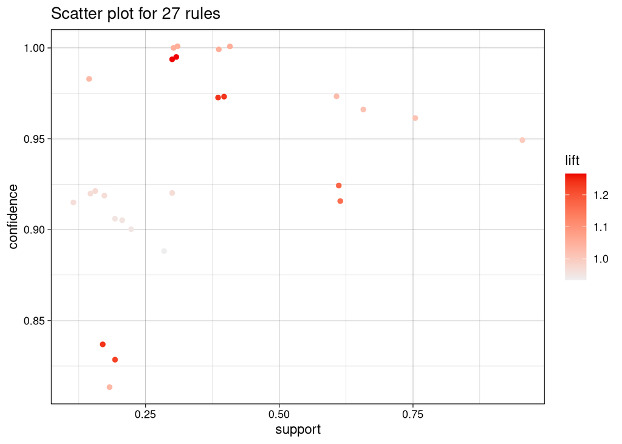

```r
library(arulesViz)
plot(AR2)
```

- Balloon plot

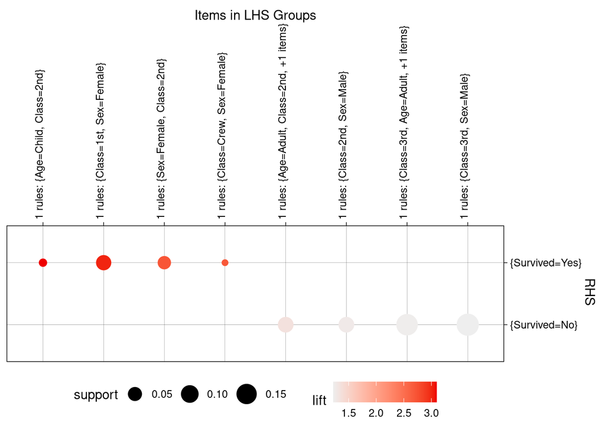

```r
plot(rules.pruned, method = "grouped")
```

- Graph-based visualizations

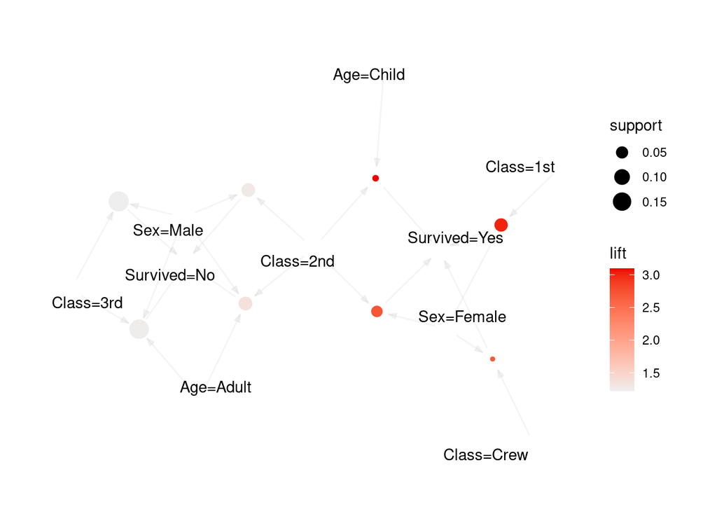

```r
plot(rules.pruned, method = "graph")
```

## Association Rules using ECLAT: AdultUCI example

### Dataset

The AdultUCI data set contains the questionnaire data of the “Adult” database (originally called the “Census Income” Database) formatted as a data.frame. This data set contains 48842 observations on following 15 variables.

```r
data("AdultUCI")
str(AdultUCI)
```

```
## 'data.frame':    48842 obs. of  15 variables:
##  $ age           : int  39 50 38 53 28 37 49 52 31 42 ...
##  $ workclass     : Factor w/ 8 levels "Federal-gov",..: 7 6 4 4 4 4 4 6 4 4 ...
##  $ fnlwgt        : int  77516 83311 215646 234721 338409 284582 160187 209642 45781 159449 ...
##  $ education     : Ord.factor w/ 16 levels "Preschool"<"1st-4th"<..: 14 14 9 7 14 15 5 9 15 14 ...
##  $ education-num : int  13 13 9 7 13 14 5 9 14 13 ...
##  $ marital-status: Factor w/ 7 levels "Divorced","Married-AF-spouse",..: 5 3 1 3 3 3 4 3 5 3 ...
##  $ occupation    : Factor w/ 14 levels "Adm-clerical",..: 1 4 6 6 10 4 8 4 10 4 ...
##  $ relationship  : Factor w/ 6 levels "Husband","Not-in-family",..: 2 1 2 1 6 6 2 1 2 1 ...
##  $ race          : Factor w/ 5 levels "Amer-Indian-Eskimo",..: 5 5 5 3 3 5 3 5 5 5 ...
##  $ sex           : Factor w/ 2 levels "Female","Male": 2 2 2 2 1 1 1 2 1 2 ...
##  $ capital-gain  : int  2174 0 0 0 0 0 0 0 14084 5178 ...
##  $ capital-loss  : int  0 0 0 0 0 0 0 0 0 0 ...
##  $ hours-per-week: int  40 13 40 40 40 40 16 45 50 40 ...
##  $ native-country: Factor w/ 41 levels "Cambodia","Canada",..: 39 39 39 39 5 39 23 39 39 39 ...
##  $ income        : Ord.factor w/ 2 levels "small"<"large": 1 1 1 1 1 1 1 2 2 2 ...
```

```r
summary(AdultUCI)
```

```
##       age                   workclass         fnlwgt
##  Min.   :17.00   Private         :33906   Min.   :  12285
##  1st Qu.:28.00   Self-emp-not-inc: 3862   1st Qu.: 117550
##  Median :37.00   Local-gov       : 3136   Median : 178144
##  Mean   :38.64   State-gov       : 1981   Mean   : 189664
##  3rd Qu.:48.00   Self-emp-inc    : 1695   3rd Qu.: 237642
##  Max.   :90.00   (Other)         : 1463   Max.   :1490400
##                  NA's            : 2799
##         education     education-num                 marital-status
##  HS-grad     :15784   Min.   : 1.00   Divorced             : 6633
##  Some-college:10878   1st Qu.: 9.00   Married-AF-spouse    :   37
##  Bachelors   : 8025   Median :10.00   Married-civ-spouse   :22379
##  Masters     : 2657   Mean   :10.08   Married-spouse-absent:  628
##  Assoc-voc   : 2061   3rd Qu.:12.00   Never-married        :16117
##  11th        : 1812   Max.   :16.00   Separated            : 1530
##  (Other)     : 7625                   Widowed              : 1518
##            occupation            relationship                   race
##  Prof-specialty : 6172   Husband       :19716   Amer-Indian-Eskimo:  470
##  Craft-repair   : 6112   Not-in-family :12583   Asian-Pac-Islander: 1519
##  Exec-managerial: 6086   Other-relative: 1506   Black             : 4685
##  Adm-clerical   : 5611   Own-child     : 7581   Other             :  406
##  Sales          : 5504   Unmarried     : 5125   White             :41762
##  (Other)        :16548   Wife          : 2331
##  NA's           : 2809
##      sex         capital-gain    capital-loss    hours-per-week
##  Female:16192   Min.   :    0   Min.   :   0.0   Min.   : 1.00
##  Male  :32650   1st Qu.:    0   1st Qu.:   0.0   1st Qu.:40.00
##                 Median :    0   Median :   0.0   Median :40.00
##                 Mean   : 1079   Mean   :  87.5   Mean   :40.42
##                 3rd Qu.:    0   3rd Qu.:   0.0   3rd Qu.:45.00
##                 Max.   :99999   Max.   :4356.0   Max.   :99.00
##
##        native-country    income
##  United-States:43832   small:24720
##  Mexico       :  951   large: 7841
##  Philippines  :  295   NA's :16281
##  Germany      :  206
##  Puerto-Rico  :  184
##  (Other)      : 2517
##  NA's         :  857
```

For more information on the data set type ?AdultUCI.

In order to create association rules we must coerce the data frame into transactions.

There is a problem with the variables. Association rules likes factor variables. We start by checking the type of columns.

```r
typeCols <- sapply(AdultUCI, class)
```

Retrieve list of columns that are qualitative / categorical variables. All integer variables have been removed.

```r
factCols <- grep("factor", typeCols)
subAdultUCI <- AdultUCI[, factCols]
head(subAdultUCI)
```

```
##          workclass education     marital-status        occupation  relationship
## 1        State-gov Bachelors      Never-married      Adm-clerical Not-in-family
## 2 Self-emp-not-inc Bachelors Married-civ-spouse   Exec-managerial       Husband
## 3          Private   HS-grad           Divorced Handlers-cleaners Not-in-family
## 4          Private      11th Married-civ-spouse Handlers-cleaners       Husband
## 5          Private Bachelors Married-civ-spouse    Prof-specialty          Wife
## 6          Private   Masters Married-civ-spouse   Exec-managerial          Wife
##    race    sex native-country income
## 1 White   Male  United-States  small
## 2 White   Male  United-States  small
## 3 White   Male  United-States  small
## 4 Black   Male  United-States  small
## 5 Black Female           Cuba  small
## 6 White Female  United-States  small
```

```r
str(subAdultUCI)
```

```
## 'data.frame':    48842 obs. of  9 variables:
##  $ workclass     : Factor w/ 8 levels "Federal-gov",..: 7 6 4 4 4 4 4 6 4 4 ...
##  $ education     : Ord.factor w/ 16 levels "Preschool"<"1st-4th"<..: 14 14 9 7 14 15 5 9 15 14 ...
##  $ marital-status: Factor w/ 7 levels "Divorced","Married-AF-spouse",..: 5 3 1 3 3 3 4 3 5 3 ...
##  $ occupation    : Factor w/ 14 levels "Adm-clerical",..: 1 4 6 6 10 4 8 4 10 4 ...
##  $ relationship  : Factor w/ 6 levels "Husband","Not-in-family",..: 2 1 2 1 6 6 2 1 2 1 ...
##  $ race          : Factor w/ 5 levels "Amer-Indian-Eskimo",..: 5 5 5 3 3 5 3 5 5 5 ...
##  $ sex           : Factor w/ 2 levels "Female","Male": 2 2 2 2 1 1 1 2 1 2 ...
##  $ native-country: Factor w/ 41 levels "Cambodia","Canada",..: 39 39 39 39 5 39 23 39 39 39 ...
##  $ income        : Ord.factor w/ 2 levels "small"<"large": 1 1 1 1 1 1 1 2 2 2 ...
```

Now, we again coerce into transactions.

```r
Adult <- as(subAdultUCI, "transactions")
summary(Adult)
```

```
## transactions as itemMatrix in sparse format with
##  48842 rows (elements/itemsets/transactions) and
##  101 columns (items) and a density of 0.08449796
##
## most frequent items:
## native-country=United-States                   race=White
##                        43832                        41762
##            workclass=Private                     sex=Male
##                        33906                        32650
##                 income=small                      (Other)
##                        24720                       239962
##
## element (itemset/transaction) length distribution:
## sizes
##     5     6     7     8     9
##    19   971  2067 15623 30162
##
##    Min. 1st Qu.  Median    Mean 3rd Qu.    Max.
##   5.000   8.000   9.000   8.534   9.000   9.000
##
## includes extended item information - examples:
##                   labels variables       levels
## 1  workclass=Federal-gov workclass  Federal-gov
## 2    workclass=Local-gov workclass    Local-gov
## 3 workclass=Never-worked workclass Never-worked
##
## includes extended transaction information - examples:
##   transactionID
## 1             1
## 2             2
## 3             3
```

### Frequent itemsets using ECLAT

To get a feeling for the data, we start by plotting frequent items.

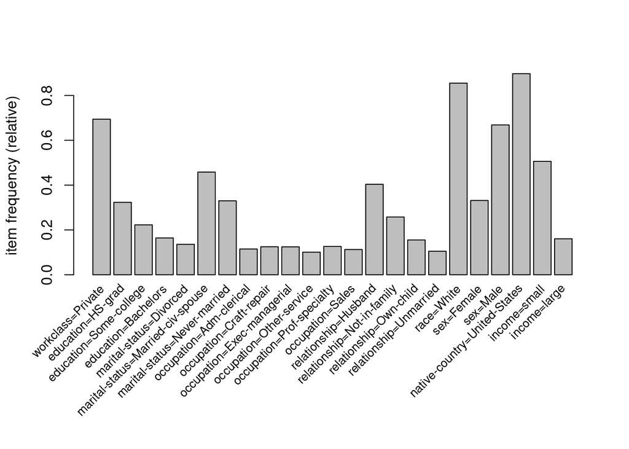

```r
itemFrequencyPlot(Adult, support = 0.1, cex.names = 0.8)
```

Let’s find the frequent itemsets:

```r
itemsets <- eclat(Adult, parameter = list(supp = 0.1, maxlen = 15), control = list(verbose = FALSE))
itemsets
```

```
## set of 326 itemsets
```

```r
summary(itemsets)
```

```
## set of 326 itemsets
##
## most frequent items:
##      native-country=United-States                        race=White
##                               154                               150
##                          sex=Male                 workclass=Private
##                               117                                93
## marital-status=Married-civ-spouse                           (Other)
##                                83                               401
##
## element (itemset/transaction) length distribution:sizes
##   1   2   3   4   5   6
##  23  78 116  78  27   4
##
##    Min. 1st Qu.  Median    Mean 3rd Qu.    Max.
##   1.000   2.000   3.000   3.061   4.000   6.000
##
## summary of quality measures:
##     support           count
##  Min.   :0.1002   Min.   : 4893
##  1st Qu.:0.1178   1st Qu.: 5752
##  Median :0.1389   Median : 6784
##  Mean   :0.1964   Mean   : 9595
##  3rd Qu.:0.2342   3rd Qu.:11438
##  Max.   :0.8974   Max.   :43832
##
## includes transaction ID lists: FALSE
##
## mining info:
##   data ntransactions support
##  Adult         48842     0.1
##                                                                                             call
##  eclat(data = Adult, parameter = list(supp = 0.1, maxlen = 15), control = list(verbose = FALSE))
```

There are many frequent iemsets. To see the 1-itemsets:

```r
singleItems <- itemsets[size(items(itemsets)) == 1]
singleItems
```

```
## set of 23 itemsets
```

### Association Rules using ECLAT

Now that we have the frequent itemsets, we construct the rules for a 70% minimum confidence.

```r
AR1_e <- ruleInduction(itemsets, confidence = .7)
AR1_e
```

```
## set of 523 rules
```

Too many rules have been obtained, let’s adjust the parameters:

```r
itemsets2 <- eclat(Adult, parameter = list(supp = 0.5, maxlen = 10), control = list(verbose = FALSE))
AR2_e <- ruleInduction(itemsets2, confidence = .8)
AR2_e
```

```
## set of 10 rules
```

```r
inspect(AR2_e)
```

```
##      lhs                               rhs                              support confidence      lift
## [1]  {sex=Male,
##       native-country=United-States} => {race=White}                   0.5415421  0.9051090 1.0585540
## [2]  {race=White,
##       sex=Male}                     => {native-country=United-States} 0.5415421  0.9204803 1.0256912
## [3]  {sex=Male}                     => {native-country=United-States} 0.5983170  0.8950383 0.9973412
## [4]  {sex=Male}                     => {race=White}                   0.5883256  0.8800919 1.0292957
## [5]  {workclass=Private,
##       native-country=United-States} => {race=White}                   0.5433848  0.8804113 1.0296693
## [6]  {workclass=Private,
##       race=White}                   => {native-country=United-States} 0.5433848  0.9144157 1.0189334
## [7]  {workclass=Private}            => {native-country=United-States} 0.6171942  0.8890757 0.9906971
## [8]  {workclass=Private}            => {race=White}                   0.5942427  0.8560137 1.0011355
## [9]  {native-country=United-States} => {race=White}                   0.7881127  0.8781940 1.0270761
## [10] {race=White}                   => {native-country=United-States} 0.7881127  0.9217231 1.0270761
```

These rules can be visualized, sorted, pruned, ….